# Computing Segregation Measures

Angel Mendiola Ross

5/8/2020

```r
knitr::opts_knit$set(root.dir = '/Users/angelmr/ps239t-final-project/')
```

## 1.0 Setup

```r
### Clear global environment
rm(list=ls())

# Set working directory
getwd()
```

```
## [1] "/Users/angelmr/ps239t-final-project"
```

```r
library(pacman)
pacman::p_unload(all)
```

```
## The following packages have been unloaded:
## pacman
```

```r
pacman::p_load(
  tidyverse, #dplyr, readr, etc.
  magrittr, #%<>% operator
  tidyr, #to transform from wide to long
  ggthemes # for pretty charts
)
```

The goal of this script is to take the data generated from the Census API and compute a series of segregation measures, beginning with the index of dissimilarity for renters.

## 1.1 Load files

The first step is to load the files I generated from the Census API as well as the crosswalk from the LODES dataset.

I downloaded the Census crosswalk from the following directory: https://lehd.ces.census.gov/data/lodes/LODES7/ca/. It includes information down to the block level. Because it is a pretty large file, I subsetted it down to California and the geographies needed. That file loads as xwalk_small.

```r
# Loading the necessary files
load("data/raw/tenure_by_tract_raw.RData")
load("data/raw/tenure_by_place_raw.RData")
load("data/raw/tenure_by_metro_raw.RData")
load("xwalks/census_xwalk_small.RData")

# the crosswalk still requires some wrangling
names(xwalk_small)
```

```
##  [1] "tabblk2010" "stname"     "cty"        "ctyname"    "trct"
##  [6] "trctname"   "bgrp"       "bgrpname"   "cbsa"       "cbsaname"
## [11] "stplc"      "stplcname"
```

```r
# dropping the block-level data
xwalk_small <- xwalk_small[c(5,6,11,12,3,4,9,10)]

xwalk_small %>% nrow() #rows in dataset=710145
```

```
## [1] 710145
```

```r
xwalk_small %>% distinct() %>% nrow() #unique rows in dataset=12500
```

```
## [1] 12500
```

```r
# deleting duplicate rows based on trct (which is the census tract)
xwalk_small %<>% distinct(trct, .keep_all = TRUE)

xwalk_small %>% distinct() %>% nrow() #unique rows in dataset=8059 and there are 8,057 tracts in CA so looks good
```

```
## [1] 8059
```

## 1.2 Joining Datasets

```r
# prepping tract-level census data for join on trct in crosswalk
tenure_by_tract %<>% dplyr::rename(trct = GEOID)

# Starting tracts as the base dataset, but need to subset for ACS years 2010-2018 because the 2009 tract data is in the 2000 boundaries
renter_seg <- tenure_by_tract %>% subset(year>2009)

# Add columns with data from the tract-place crosswalk, matching on 'GEOID' variable
renter_seg <- left_join(x = renter_seg,
                          y = xwalk_small,
                          by = "trct")

renter_seg %>% nrow() #rows in dataset=72513
```

```
## [1] 72513
```

```r
renter_seg %>% distinct() %>% nrow() #unique rows in dataset=72513
```

```
## [1] 72513
```

```r
# renaming geoid for place df "stplc" which is how it is in the crosswalk
tenure_by_place %<>% dplyr::rename(stplc = GEOID)

# Add columns with place-level variables to renter_seg, matching on 'year' & 'PLACE_GEOID' variable
renter_seg <- left_join(x = renter_seg,
                          y = tenure_by_place,
                          by = c('year', 'stplc'))


renter_seg %>% nrow() #rows in dataset=72513
```

```
## [1] 72513
```

```r
renter_seg %>% distinct() %>% nrow() #unique rows in dataset=72513
```

```
## [1] 72513
```

```r
# renaming geoid in the metro data to "cbsa"
tenure_by_metro %<>% dplyr::rename(cbsa = GEOID)

# chaning cbsa to a character variable in the renter_seg dataframe
renter_seg$cbsa <- as.character(renter_seg$cbsa)

# Add columns with metro-level variables to renter_seg, matching on 'year' & 'PLACE_GEOID' variable
renter_seg <- left_join(x = renter_seg,
                          y = tenure_by_metro,
                          by = c('year', 'cbsa'))
```

## 1.3 Cleaning the Merged Renter Segregation Dataframe

```r
# first step is viewing names and assigning variable names that make sense
names(renter_seg)
```

```
##  [1] "year"         "trct"         "NAME.x"       "total_hhs.x"  "owner_hhs.x"
##  [6] "renter_hhs.x" "total_pop.x"  "nhw.x"        "nhb.x"        "nha.x"
## [11] "his.x"        "trctname"     "stplc"        "stplcname"    "cty"
## [16] "ctyname"      "cbsa"         "cbsaname"     "NAME.y"       "total_hhs.y"
## [21] "owner_hhs.y"  "renter_hhs.y" "total_pop.y"  "nhw.y"        "nhb.y"
## [26] "nha.y"        "his.y"        "NAME"         "metro"        "total_hhs"
## [31] "owner_hhs"    "renter_hhs"   "total_pop"    "nhw"          "nhb"
## [36] "nha"          "his"
```

```r
# starting with renaming renter variables
renter_seg %<>% dplyr::rename(renters_tract = renter_hhs.x)
renter_seg %<>% dplyr::rename(renters_place = renter_hhs.y)
renter_seg %<>% dplyr::rename(renters_metro = renter_hhs)

# now renaming homeowner variables
renter_seg %<>% dplyr::rename(owners_tract = owner_hhs.x)
renter_seg %<>% dplyr::rename(owners_place = owner_hhs.y)
renter_seg %<>% dplyr::rename(owners_metro = owner_hhs)

# renaming total households variables
renter_seg %<>% dplyr::rename(hhs_tract = total_hhs.x)
renter_seg %<>% dplyr::rename(hhs_place = total_hhs.y)
renter_seg %<>% dplyr::rename(hhs_metro = total_hhs)

# moving on to demographic variables
renter_seg %<>% dplyr::rename(total_pop_tract = total_pop.x)
renter_seg %<>% dplyr::rename(total_pop_place = total_pop.y)
renter_seg %<>% dplyr::rename(total_pop_metro = total_pop)

# non-hispanic white variable
renter_seg %<>% dplyr::rename(nhw_tract = nhw.x)
renter_seg %<>% dplyr::rename(nhw_place = nhw.y)
renter_seg %<>% dplyr::rename(nhw_metro = nhw)

# non-hispanic black variable
renter_seg %<>% dplyr::rename(nhb_tract = nhb.x)
renter_seg %<>% dplyr::rename(nhb_place = nhb.y)
renter_seg %<>% dplyr::rename(nhb_metro = nhb)

# non-hispanic asian variable
renter_seg %<>% dplyr::rename(nha_tract = nha.x)
renter_seg %<>% dplyr::rename(nha_place = nha.y)
renter_seg %<>% dplyr::rename(nha_metro = nha)

# and hispanic/latino variable
renter_seg %<>% dplyr::rename(his_tract = his.x)
renter_seg %<>% dplyr::rename(his_place = his.y)
renter_seg %<>% dplyr::rename(his_metro = his)

# now changing the "NAME" variables
renter_seg %<>% dplyr::rename(tract_name = NAME.x)
renter_seg %<>% dplyr::rename(place_name = NAME.y)
renter_seg %<>% dplyr::rename(cbsa_name = NAME)

# rearranging the columns so that the geo columns correspond to the data better
renter_seg <- renter_seg[c(1:14,19:27,15:18,28:37)]

# saving combined renter_seg data
save(renter_seg,
     file="data/renter_seg.RData")
```

## 1.4 Computing Renter Segregation (index of dissimilarity)

Now that the dataset is cleanly labeled and ordered, I will begin computing the variables necessary for the index of dissimilarity for renters-homeowners.

The formula for the index of dissimilarity that I use is here is based on Massey and Denton’s (1988) “The Dimensions of Residential Segregation.” It is also described in the Census Bureau’s Measures of Segregation appendix: https://www.census.gov/hhes/www/housing/resseg/pdf/app_b.pdf. (see top right of page 122)

```r
## NOTE: I use the dplyr:: prefix in the following chunk because group_by does not work without it due to plyr

# computing the necessary renter proportions for tracts and for cities
renter_seg %<>%
  dplyr::mutate(prenter_tract = renters_tract/hhs_tract)

renter_seg %<>%
  dplyr::mutate(prenter_city = renters_place/hhs_place)

# computing absolute difference of the two proportions
renter_seg %<>%
  dplyr::mutate(prenter_abs_diff = abs(prenter_tract - prenter_city))

# computing the numerator of the index of dissimilarity (based on city-level data)
renter_seg %<>%
  dplyr::group_by(place_name, year) %>%
  dplyr::mutate(diss_num_city = sum(hhs_tract*prenter_abs_diff, na.rm=TRUE)) %>%
  dplyr::ungroup()

# assign NAs if there is no city-level data
renter_seg %<>%
  dplyr::mutate(diss_num_city = ifelse(is.na(prenter_city), NA, diss_num_city))

# computing T
renter_seg %<>%
  dplyr::group_by(place_name, year) %>%
  dplyr::mutate(T_diss = sum(hhs_tract, na.rm=TRUE)) %>%
  dplyr::ungroup()

# computing X
renter_seg %<>%
  dplyr::group_by(place_name, year) %>%
  dplyr::mutate(X_diss = sum(renters_tract, na.rm=TRUE)) %>%
  dplyr::ungroup()

# computing P (ratio of X to T)
renter_seg %<>%
  dplyr::mutate(P_diss = X_diss / T_diss)

# adding a variable for the number of tracts in each city
renter_seg %<>%
  dplyr::group_by(place_name, year) %>%
  dplyr::mutate(n_tracts = n())

# checking to see if the large differences between the cities and tracts are due to cities with only a small number of tracts within in
renter_seg %>%
  dplyr::mutate(diff_P_city = P_diss - prenter_city) %>%
  subset(diff_P_city>.30) %>%
  dplyr::select("year","place_name","prenter_city","P_diss","diff_P_city","n_tracts")
```

```
## # A tibble: 38 x 6
## # Groups:   place_name, year [38]
##    year  place_name                     prenter_city P_diss diff_P_city n_tracts
##    <chr> <chr>                                 <dbl>  <dbl>       <dbl>    <int>
##  1 2010  San Miguel CDP (Contra Costa …       0.0788  0.475       0.396        1
##  2 2010  Comptche CDP, California             0       0.371       0.371        1
##  3 2010  Lincoln Village CDP, Californ…       0.298   0.699       0.401        1
##  4 2010  Loma Mar CDP, California             0       0.326       0.326        1
##  5 2011  San Miguel CDP (Contra Costa …       0.0762  0.513       0.437        1
##  6 2011  Comptche CDP, California             0       0.356       0.356        1
##  7 2011  Soledad city, California             0.418   1           0.582        1
##  8 2011  Lincoln Village CDP, Californ…       0.324   0.693       0.368        1
##  9 2012  Pacheco CDP, California              0.217   0.519       0.302        1
## 10 2012  San Miguel CDP (Contra Costa …       0.0969  0.513       0.416        1
## # … with 28 more rows
```

```r
renter_seg %>%
  dplyr::mutate(diff_P_city = P_diss - prenter_city) %>%
  subset(diff_P_city<(-.30)) %>%
  dplyr::select("year","place_name","prenter_city","P_diss","diff_P_city","n_tracts")
```

```
## # A tibble: 59 x 6
## # Groups:   place_name, year [23]
##    year  place_name                  prenter_city P_diss diff_P_city n_tracts
##    <chr> <chr>                              <dbl>  <dbl>       <dbl>    <int>
##  1 2010  Industry city, California          0.662  0.319      -0.343        5
##  2 2010  Industry city, California          0.662  0.319      -0.343        5
##  3 2010  Industry city, California          0.662  0.319      -0.343        5
##  4 2010  Industry city, California          0.662  0.319      -0.343        5
##  5 2010  Industry city, California          0.662  0.319      -0.343        5
##  6 2010  Oakville CDP, California           1      0.117      -0.883        1
##  7 2010  Camp Nelson CDP, California        0.731  0.258      -0.473        1
##  8 2011  Industry city, California          0.862  0.288      -0.574        5
##  9 2011  Industry city, California          0.862  0.288      -0.574        5
## 10 2011  Industry city, California          0.862  0.288      -0.574        5
## # … with 49 more rows
```

```r
# The only big issues here are the city of Industry and Rancho Santa Margarita

# computing the dissimilarity denominator (based on aggregated tract-level data): (2PT)(1-P)
renter_seg %<>%
  dplyr::group_by(place_name, year) %>%
  dplyr::mutate(diss_denom = 2*(P_diss*T_diss)*(1-P_diss)) %>%
  dplyr::ungroup()

# computing the numerator of the index of dissimilarity (based on aggregated tract-level data): sum(hhs_tract)*abs(prenter_tract-P_diss)

# first computing pi_abs_diff
renter_seg %<>%
  dplyr::mutate(pi_abs_diff = abs(prenter_tract - P_diss))

# now the numerator
renter_seg %<>%
  dplyr::group_by(place_name, year) %>%
  dplyr::mutate(diss_num = sum(hhs_tract*pi_abs_diff, na.rm=TRUE)) %>%
  dplyr::ungroup()

# computing the dissimilarity denominator (based on city-level data): (2PT)(1-P)
renter_seg %<>%
  dplyr::group_by(place_name, year) %>%
  dplyr::mutate(diss_denom_city = 2*(hhs_place*prenter_city)*(1-prenter_city)) %>%
  dplyr::ungroup()

# now finally computing the renter-owner index of dissimilarity

# based on city-level data
renter_seg %<>%
  dplyr::mutate(diss_index_city = diss_num_city / diss_denom_city)

# based on aggregated tract-level data
renter_seg %<>%
  dplyr::mutate(diss_index = diss_num / diss_denom)
```

## 1.5 Transforming Data Frame into City-level Data

Even though this is only for the 2010 to 2018 data and we would not expect much variation in such a short time frame for something like housing, I want to see if there is any variation.

I have my data right now organized by census tract. But now that I computed the dissimilarity index, I want it organized by place (or city). So, first I will create a new dataframe with cities as the main unit of analysis and compute some summary statistics.

```r
# stripping data frame down to just cities
renter_seg_city <- distinct(renter_seg, year, stplc, .keep_all = TRUE)

# looking at summary stats
renter_seg_city %>%
  subset(!is.na(cbsa) & !is.na(place_name)) %>%
  select(n_tracts) %>%
  summary(n_tracts)
```

```
##     n_tracts
##  Min.   :   1.00
##  1st Qu.:   1.00
##  Median :   4.00
##  Mean   :  10.41
##  3rd Qu.:  10.00
##  Max.   :1003.00
```

```r
# assigning as NA the 27 values that are infinity
renter_seg_city %<>%
  dplyr::mutate(diss_index_city = ifelse(diss_index_city>10000, NA, diss_index_city))

# now I can see the true mean for the dissimilarity index based on city-level variables
renter_seg_city %>%
  subset(!is.na(cbsa) & !is.na(place_name)) %>%
  select(diss_index, diss_index_city, n_tracts) %>%
  summary(diss_index)
```

```
##    diss_index     diss_index_city       n_tracts
##  Min.   :0.0000   Min.   :  0.0000   Min.   :   1.00
##  1st Qu.:0.0000   1st Qu.:  0.1121   1st Qu.:   1.00
##  Median :0.2081   Median :  0.2230   Median :   4.00
##  Mean   :0.1910   Mean   :  0.7639   Mean   :  10.41
##  3rd Qu.:0.3192   3rd Qu.:  0.3337   3rd Qu.:  10.00
##  Max.   :0.6693   Max.   :610.8819   Max.   :1003.00
##  NA's   :15       NA's   :39
```

```r
# there are some values that are very high on the city-level index that are skewing the mean

# if I subset to cities/places with diss_index_city is less than 1, the means and medians are much closer
renter_seg_city %>%
  subset(!is.na(cbsa) & !is.na(place_name) & diss_index_city<1) %>%
  select(diss_index, diss_index_city, n_tracts) %>%
  summary(diss_index)
```

```
##    diss_index     diss_index_city     n_tracts
##  Min.   :0.0000   Min.   :0.0000   Min.   :   1.00
##  1st Qu.:0.0000   1st Qu.:0.1073   1st Qu.:   1.00
##  Median :0.2146   Median :0.2164   Median :   4.00
##  Mean   :0.1953   Mean   :0.2294   Mean   :  10.79
##  3rd Qu.:0.3206   3rd Qu.:0.3200   3rd Qu.:  10.00
##  Max.   :0.6693   Max.   :0.9962   Max.   :1003.00
##  NA's   :15
```

## 1.6 Plotting the Dissimilarity Index Over Time

To get a feel for my data and prepare for plotting, I will transform the year variable (which was coerced into a character during an earlier join) into a numeric and compute yearly means.

```r
renter_seg_city$year <- as.numeric(as.character(renter_seg_city$year))

# creating summary dfs to plot
means <- renter_seg_city %>%
  group_by(year) %>%
  summarise(diss_index = mean(diss_index, na.rm = T))

means_city <- renter_seg_city %>%
  group_by(year) %>%
  summarise(diss_index_city = mean(diss_index_city, na.rm = T))

# checking yearly means
means
```

```
## # A tibble: 9 x 2
##    year diss_index
##   <dbl>      <dbl>
## 1  2010      0.203
## 2  2011      0.198
## 3  2012      0.194
## 4  2013      0.191
## 5  2014      0.189
## 6  2015      0.188
## 7  2016      0.186
## 8  2017      0.186
## 9  2018      0.187
```

```r
means_city
```

```
## # A tibble: 9 x 2
##    year diss_index_city
##   <dbl>           <dbl>
## 1  2010           0.560
## 2  2011           0.625
## 3  2012           1.34
## 4  2013           0.887
## 5  2014           0.742
## 6  2015           0.541
## 7  2016           0.582
## 8  2017           0.592
## 9  2018           1.00
```

Now I can plot renter segregation based on both indices of dissimilairy. This one is using the aggregated tract-level measure (rather than actual city-level data):

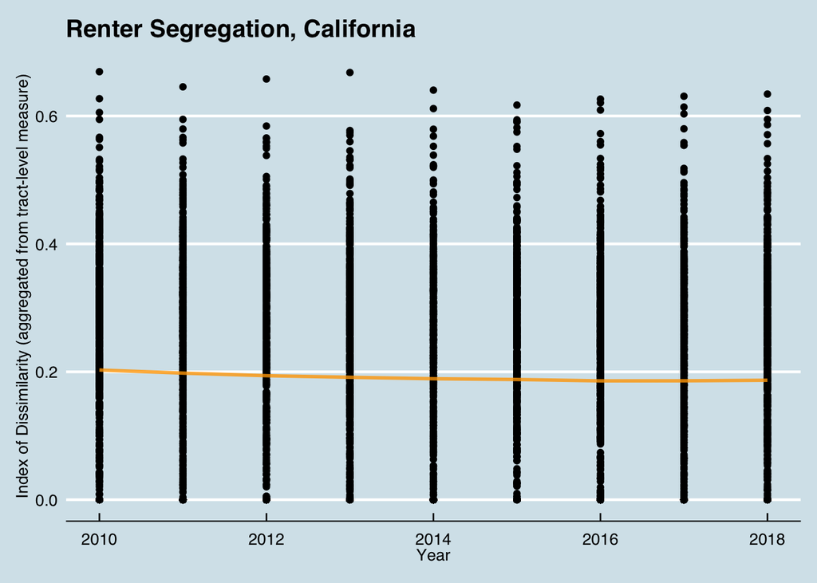

And this one is using the actually city-level data. Note that the index is only suppose to range from 0 to 1 but because this is based on the city-level data rather than tract aggregates, there are some cities where the index is greater than 1 because census tract boundaries are not cleanly divided by cities.

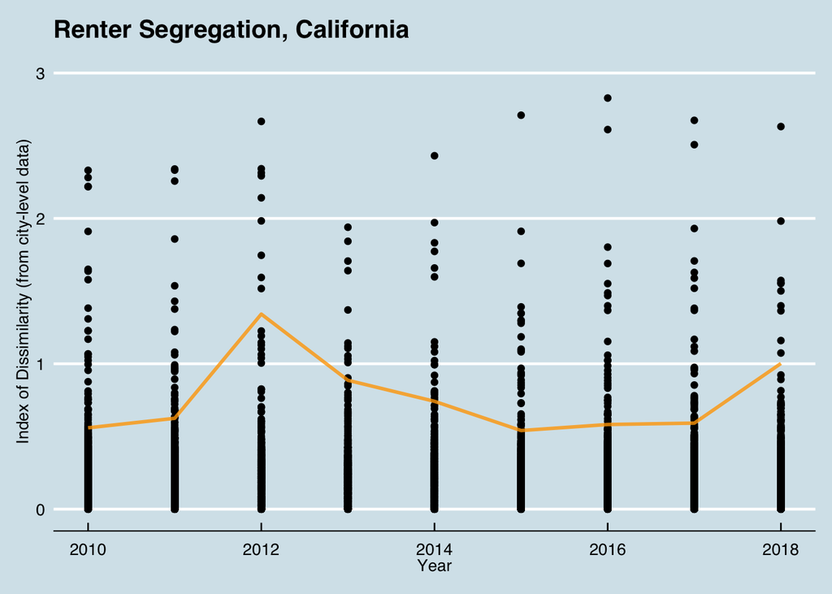

## 1.7 Saving Renter Segregation Data

I don’t need all variables in the dataframe for my main policing analysis, so here I am reducing the file down a bit and saving to an RData file.

```r
# checking names
names(renter_seg_city)
```

```
##  [1] "year"             "trct"             "tract_name"       "hhs_tract"
##  [5] "owners_tract"     "renters_tract"    "total_pop_tract"  "nhw_tract"
##  [9] "nhb_tract"        "nha_tract"        "his_tract"        "trctname"
## [13] "stplc"            "stplcname"        "place_name"       "hhs_place"
## [17] "owners_place"     "renters_place"    "total_pop_place"  "nhw_place"
## [21] "nhb_place"        "nha_place"        "his_place"        "cty"
## [25] "ctyname"          "cbsa"             "cbsaname"         "cbsa_name"
## [29] "metro"            "hhs_metro"        "owners_metro"     "renters_metro"
## [33] "total_pop_metro"  "nhw_metro"        "nhb_metro"        "nha_metro"
## [37] "his_metro"        "prenter_tract"    "prenter_city"     "prenter_abs_diff"
## [41] "diss_num_city"    "T_diss"           "X_diss"           "P_diss"
## [45] "n_tracts"         "diss_denom"       "pi_abs_diff"      "diss_num"
## [49] "diss_denom_city"  "diss_index_city"  "diss_index"
```

```r
# selecting necessary variables
renter_seg_city <- renter_seg_city[c(1,13:37,45,51,50)]

# saving to data folder
save(renter_seg_city,
     file = "data/renter_seg_city.RData")
```